# 002 prolonged symptoms

Katie Gostic

11/1/2017

Notes on data formatting from Deborah Wentworth:

- symdur is symptom duration (days) prior to enrollment
- date info is for enrollment date
- fluvac6 and fluvac12 are flu vaccination in last 6 or last 12 months
- anyvac combines values from fluvac6 and fluvac12, whichever was collected for a given patient is reported.
- anyav is use of antivirals at any time
- anydx is any diagnosis in the medical history section
- flutype is subtype: 1=H1N1, 2=H3N2, 3=flu B, 4=PCR negative, 5=Inf A, subtype unknown, and 6=coinfection with multiple strains
- resolved is symptom resolution within 14 days
- country code is the 3 letter code for country of enrollment - think the abbreviations will be obvious

Notes on duration of symptoms: A review by Carrat et al. (2007) of challenge studies in healthy human volunteers suggests that influenza symptoms typically resolve fully within 8-9 days of inoculation. This led us to classify patients with the following characteristics as having long-lasting symptoms:

- Symptoms lasting 10 or more days prior to study enrollment (this implies that symptoms on day 10 were still serious enough to send patients to the doctor, and most likely lasted at least a few days longer.)
- Symptoms not resolved on day 14 of enrollment (implies that symptoms lasted longer than 14 days, as most patients had symptoms for at least one day prior to enrollment.)

```r
# use the above definition to define a column for prolonged symptoms
dat.002$prolonged.symp = as.numeric(dat.002$symdur >= 10 | dat.002$resolved == "0")
```

#### Visualize the relationship between age and prob of H1N1 infection

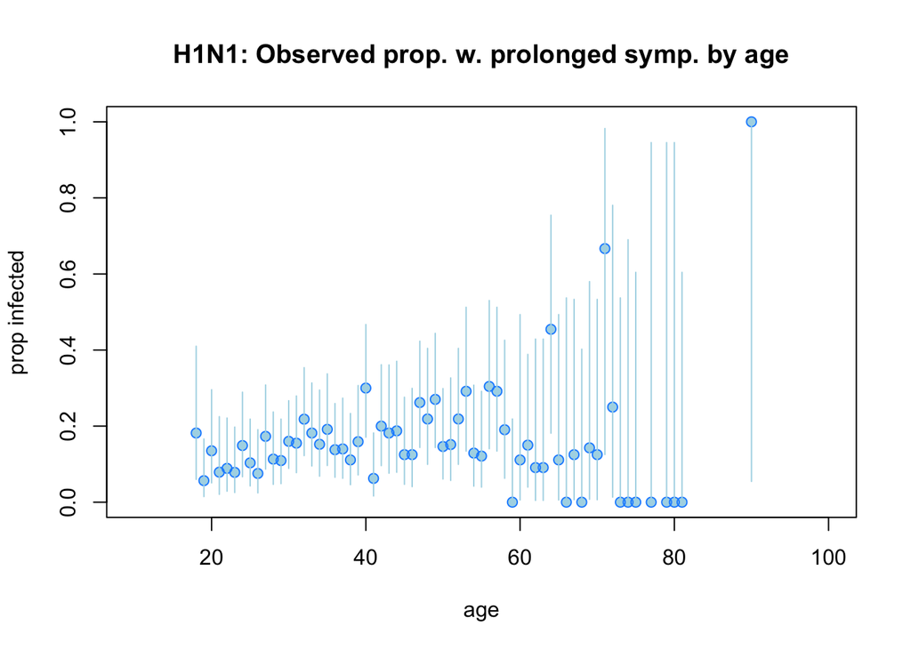

#### Visualize the relationship between age and prob of H3N2 infection

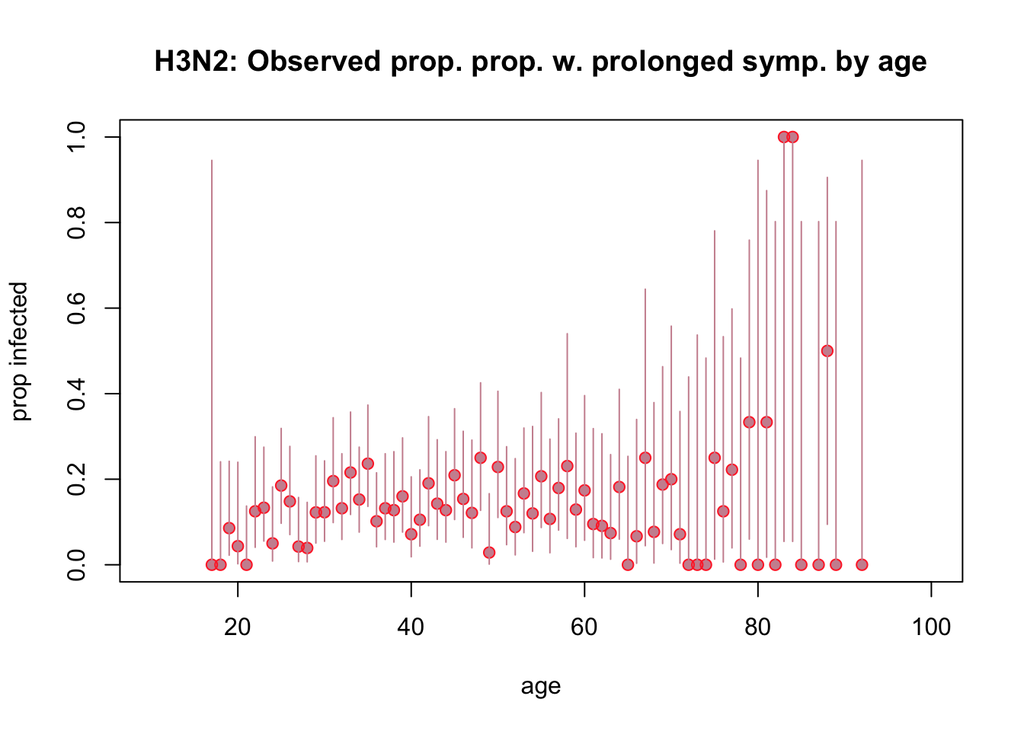

#### Visualize the relationship between country and prolonged symptoms

H1N1

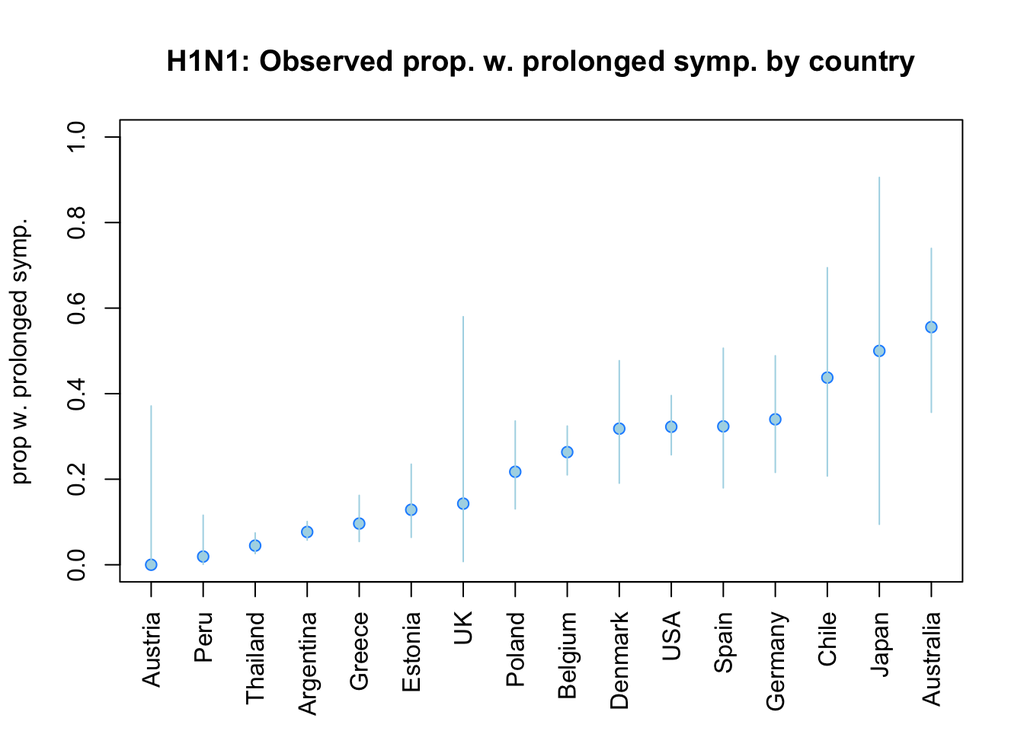

H3N2

[figure not shown]

#### Visualize the relationship between season and prob infection

H1N1

[figure not shown]

H3N2

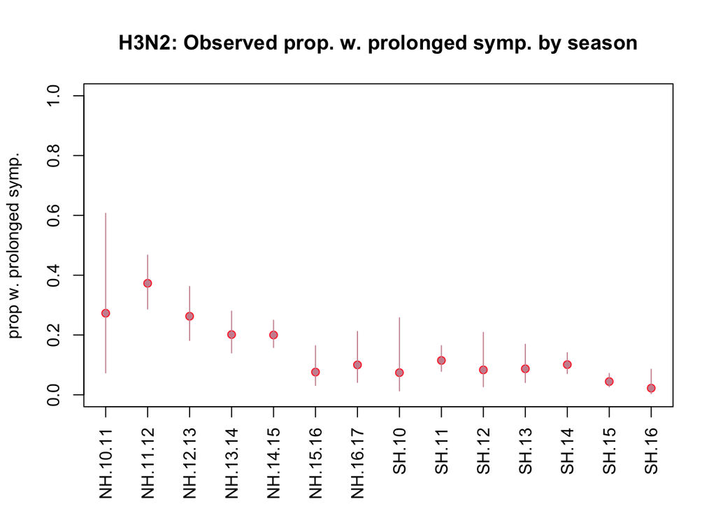

## Set up a logistic regression that includes the following predictors:

- age
- imprinting status
- vaccination status
- antiviral use
- season
- country

### Clean data for fitting

```
##
## Argentina Australia   Austria   Belgium     Chile   Denmark   Estonia
##       626        27         9       243        16        44        70
##   Germany    Greece     Japan      Peru    Poland     Spain  Thailand
##        50       135         2        52        69        34       335
##        UK       USA
##         7       186
```

```
## [1] 1905
```

### First fit a model where the only independent variable is age

Treat vaccination, antivial use, underlying symptoms, country and season as blocking variables with fixed effects

```r
library(ROCR)
```

```r
library(splines)
## H1N1 fit to country, season and medical history only (no effect of age or imprinting)
fit0 = glm(prolonged.symp ~ anyvac + anyav + anydx + country + season, data = train.H1N1, family = binomial)
summary(fit0)
```

```
##
## Call:
## glm(formula = prolonged.symp ~ anyvac + anyav + anydx + country +
##     season, family = binomial, data = train.H1N1)
##
## Deviance Residuals:
##     Min       1Q   Median       3Q      Max
## -1.7388  -0.6695  -0.3411  -0.2633   2.7231
##
## Coefficients:
##                    Estimate Std. Error z value Pr(>|z|)
## (Intercept)      -2.401e+00  1.104e+00  -2.174   0.0297 *
## anyvac1           1.916e-01  2.656e-01   0.722   0.4706
## anyvac2           1.227e+00  1.460e+00   0.841   0.4005
## anyav1            1.547e-01  2.647e-01   0.584   0.5589
## anydx1            3.381e-01  2.295e-01   1.473   0.1407
## countryAustralia  2.326e+00  1.229e+00   1.892   0.0584 .
## countryBelgium    1.087e+00  1.108e+00   0.981   0.3266
## countryDenmark    1.758e+00  1.157e+00   1.520   0.1286
## countryEstonia    4.415e-01  1.179e+00   0.375   0.7080
## countryGermany    6.750e-01  1.190e+00   0.567   0.5705
## countryGreece    -7.786e-01  1.200e+00  -0.649   0.5165
## countryOther      8.777e-02  1.140e+00   0.077   0.9387
## countryPeru      -1.212e+00  1.064e+00  -1.139   0.2547
## countryPoland     9.555e-01  1.150e+00   0.831   0.4062
## countrySpain      1.206e+00  1.188e+00   1.015   0.3099
## countryThailand  -1.275e+00  1.087e+00  -1.172   0.2411
## countryUSA        1.227e+00  1.104e+00   1.112   0.2663
## seasonNH.10.11    2.179e-01  5.051e-01   0.431   0.6662
## seasonNH.11.12   -1.539e+01  2.400e+03  -0.006   0.9949
## seasonNH.12.13    6.291e-01  4.190e-01   1.501   0.1333
## seasonNH.13.14   -7.332e-03  3.881e-01  -0.019   0.9849
## seasonNH.14.15    9.259e-02  5.175e-01   0.179   0.8580
## seasonNH.15.16    2.779e-01  3.326e-01   0.835   0.4034
## seasonNH.16.17   -1.301e+01  8.453e+02  -0.015   0.9877
## seasonSH.10       9.030e-01  7.819e-01   1.155   0.2481
## seasonSH.11       9.989e-01  1.020e+00   0.979   0.3276
## seasonSH.12      -4.071e-01  1.492e+00  -0.273   0.7849
## seasonSH.13       5.267e-01  1.113e+00   0.473   0.6361
## seasonSH.14      -1.360e+01  4.980e+02  -0.027   0.9782
## seasonSH.15      -4.152e-01  1.423e+00  -0.292   0.7704
## seasonSH.16      -7.522e-01  1.123e+00  -0.670   0.5029
## ---
## Signif. codes:  0 '***' 0.001 '**' 0.01 '*' 0.05 '.' 0.1 ' ' 1
##
## (Dispersion parameter for binomial family taken to be 1)
##
##     Null deviance: 921.77  on 1064  degrees of freedom
## Residual deviance: 773.25  on 1034  degrees of freedom
## AIC: 835.25
##
## Number of Fisher Scoring iterations: 15
```

```r
## H1N1 fit to age only, plus fixed effects of vaccination, av use, underlying conditions, country and season
fit1 = glm(prolonged.symp ~ ns(age, knots = 65) + anyvac + anyav + anydx + country + season, data = train.H1N1, family = binomial)
summary(fit1)
```

```
##
## Call:
## glm(formula = prolonged.symp ~ ns(age, knots = 65) + anyvac +
##     anyav + anydx + country + season, family = binomial, data = train.H1N1)
##
## Deviance Residuals:
##     Min       1Q   Median       3Q      Max
## -1.7241  -0.6533  -0.3332  -0.2589   2.7332
##
## Coefficients:
##                        Estimate Std. Error z value Pr(>|z|)
## (Intercept)            -2.51618    1.11046  -2.266   0.0235 *
## ns(age, knots = 65)1    0.81574    0.65991   1.236   0.2164
## ns(age, knots = 65)2    0.35205    0.91051   0.387   0.6990
## anyvac1                 0.12590    0.27172   0.463   0.6431
## anyvac2                 1.20263    1.46184   0.823   0.4107
## anyav1                  0.16250    0.26626   0.610   0.5417
## anydx1                  0.27348    0.23577   1.160   0.2461
## countryAustralia        2.27392    1.22769   1.852   0.0640 .
## countryBelgium          1.04041    1.10782   0.939   0.3477
## countryDenmark          1.73249    1.15604   1.499   0.1340
## countryEstonia          0.43058    1.17795   0.366   0.7147
## countryGermany          0.66420    1.19055   0.558   0.5769
## countryGreece          -0.81168    1.19947  -0.677   0.4986
## countryOther            0.06204    1.13072   0.055   0.9562
## countryPeru            -1.23196    1.06440  -1.157   0.2471
## countryPoland           0.92426    1.14913   0.804   0.4212
## countrySpain            1.17536    1.18791   0.989   0.3224
## countryThailand        -1.28817    1.08546  -1.187   0.2353
## countryUSA              1.25821    1.10324   1.140   0.2541
## seasonNH.10.11          0.18275    0.50700   0.360   0.7185
## seasonNH.11.12        -15.49298 2399.54474  -0.006   0.9948
## seasonNH.12.13          0.56590    0.42492   1.332   0.1829
## seasonNH.13.14         -0.08404    0.39582  -0.212   0.8319
## seasonNH.14.15          0.04928    0.52018   0.095   0.9245
## seasonNH.15.16          0.20042    0.34115   0.587   0.5569
## seasonNH.16.17        -13.08065  845.70998  -0.015   0.9877
## seasonSH.10             0.89907    0.78167   1.150   0.2501
## seasonSH.11             0.95405    1.02348   0.932   0.3513
## seasonSH.12            -0.51974    1.49592  -0.347   0.7283
## seasonSH.13             0.45907    1.11331   0.412   0.6801
## seasonSH.14           -13.63855  497.90706  -0.027   0.9781
## seasonSH.15            -0.49792    1.43077  -0.348   0.7278
## seasonSH.16            -0.83424    1.12402  -0.742   0.4580
## ---
## Signif. codes:  0 '***' 0.001 '**' 0.01 '*' 0.05 '.' 0.1 ' ' 1
##
## (Dispersion parameter for binomial family taken to be 1)
##
##     Null deviance: 921.77  on 1064  degrees of freedom
## Residual deviance: 771.73  on 1032  degrees of freedom
## AIC: 837.73
##
## Number of Fisher Scoring iterations: 15
```

```r
## H1N1 fit to age plus imprinting, plus fixed effects of vaccination, av use, underlying conditions, country and season
fit2 = glm(prolonged.symp ~ ns(age, knots = 65) + p.g1.protection + anyvac + anyav + anydx + country + season, data = train.H1N1, family = binomial)
summary(fit2)
```

```
##
## Call:
## glm(formula = prolonged.symp ~ ns(age, knots = 65) + p.g1.protection +
##     anyvac + anyav + anydx + country + season, family = binomial,
##     data = train.H1N1)
##
## Deviance Residuals:
##     Min       1Q   Median       3Q      Max
## -1.7256  -0.6530  -0.3281  -0.2629   2.7358
##
## Coefficients:
##                        Estimate Std. Error z value Pr(>|z|)
## (Intercept)            -2.58382    1.11945  -2.308   0.0210 *
## ns(age, knots = 65)1    0.44872    0.92020   0.488   0.6258
## ns(age, knots = 65)2    0.03377    1.07999   0.031   0.9751
## p.g1.protection         0.22436    0.39088   0.574   0.5660
## anyvac1                 0.13562    0.27249   0.498   0.6187
## anyvac2                 1.26553    1.46448   0.864   0.3875
## anyav1                  0.16800    0.26660   0.630   0.5286
## anydx1                  0.27374    0.23588   1.161   0.2458
## countryAustralia        2.29765    1.22813   1.871   0.0614 .
## countryBelgium          1.04390    1.11009   0.940   0.3470
## countryDenmark          1.72586    1.15831   1.490   0.1362
## countryEstonia          0.45319    1.18044   0.384   0.7010
## countryGermany          0.66797    1.19290   0.560   0.5755
## countryGreece          -0.79664    1.20182  -0.663   0.5074
## countryOther            0.03479    1.13370   0.031   0.9755
## countryPeru            -1.23022    1.06512  -1.155   0.2481
## countryPoland           0.93269    1.15131   0.810   0.4179
## countrySpain            1.18607    1.19295   0.994   0.3201
## countryThailand        -1.27939    1.08571  -1.178   0.2386
## countryUSA              1.25723    1.10582   1.137   0.2556
## seasonNH.10.11          0.19944    0.50769   0.393   0.6944
## seasonNH.11.12        -15.41517 2399.54474  -0.006   0.9949
## seasonNH.12.13          0.59637    0.42829   1.392   0.1638
## seasonNH.13.14         -0.05017    0.40010  -0.125   0.9002
## seasonNH.14.15          0.08956    0.52467   0.171   0.8645
## seasonNH.15.16          0.24856    0.35148   0.707   0.4794
## seasonNH.16.17        -13.04911  846.83146  -0.015   0.9877
## seasonSH.10             0.88912    0.78143   1.138   0.2552
## seasonSH.11             0.97940    1.02714   0.954   0.3403
## seasonSH.12            -0.48265    1.49894  -0.322   0.7475
## seasonSH.13             0.48894    1.11678   0.438   0.6615
## seasonSH.14           -13.60614  497.35163  -0.027   0.9782
## seasonSH.15            -0.48628    1.43105  -0.340   0.7340
## seasonSH.16            -0.79182    1.12939  -0.701   0.4832
## ---
## Signif. codes:  0 '***' 0.001 '**' 0.01 '*' 0.05 '.' 0.1 ' ' 1
##
## (Dispersion parameter for binomial family taken to be 1)
##
##     Null deviance: 921.77  on 1064  degrees of freedom
## Residual deviance: 771.40  on 1031  degrees of freedom
## AIC: 839.4
##
## Number of Fisher Scoring iterations: 15
```

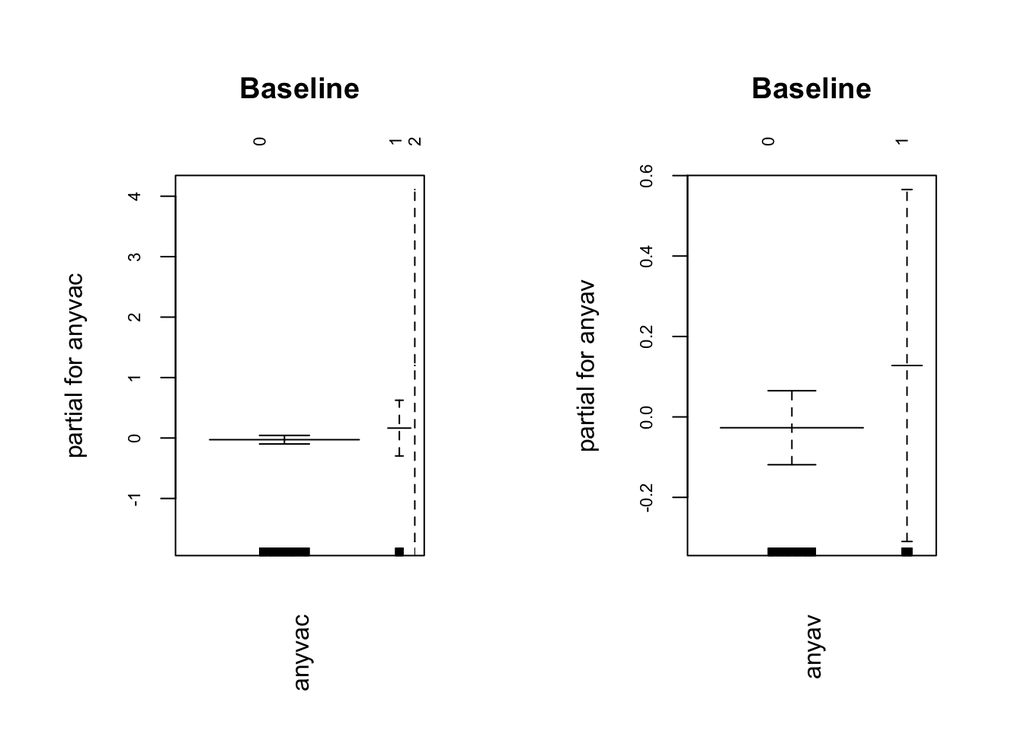

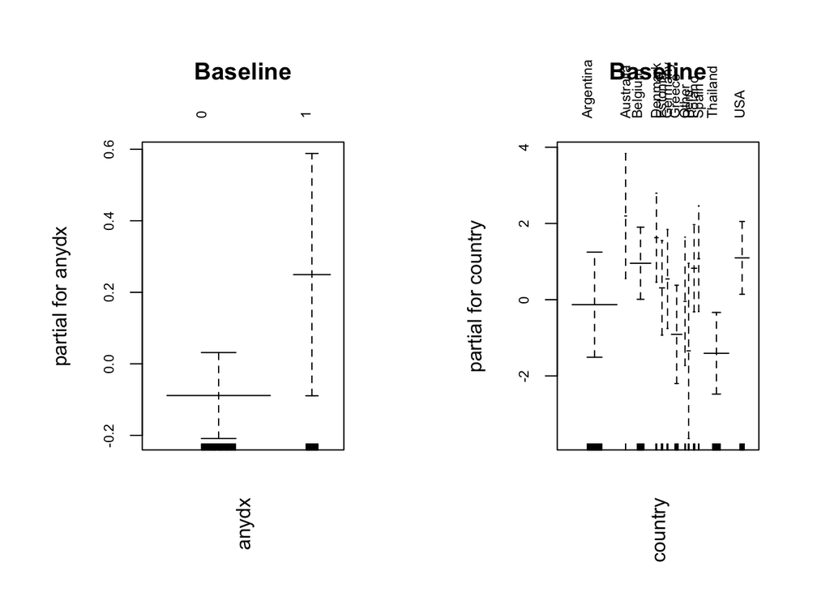

```r
## Plot the fits for each model side by side
par(mfrow = c(1, 2), las = 3, mar = c(6, 6, 6, 3), cex.axis = .7)
library(gam)
plot.gam(fit0, se = T, col = 'dodgerblue', main = 'Baseline')
```

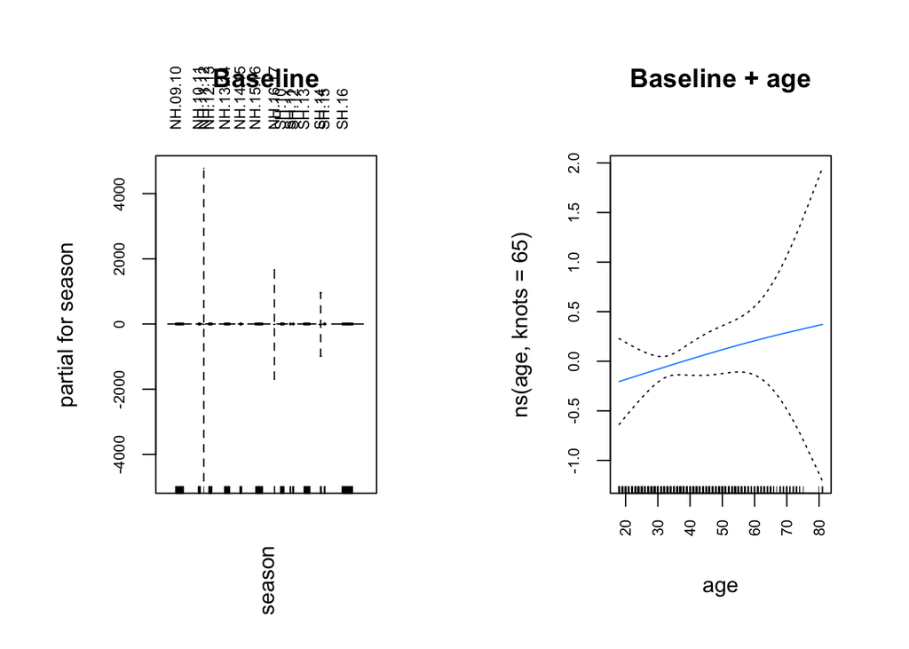

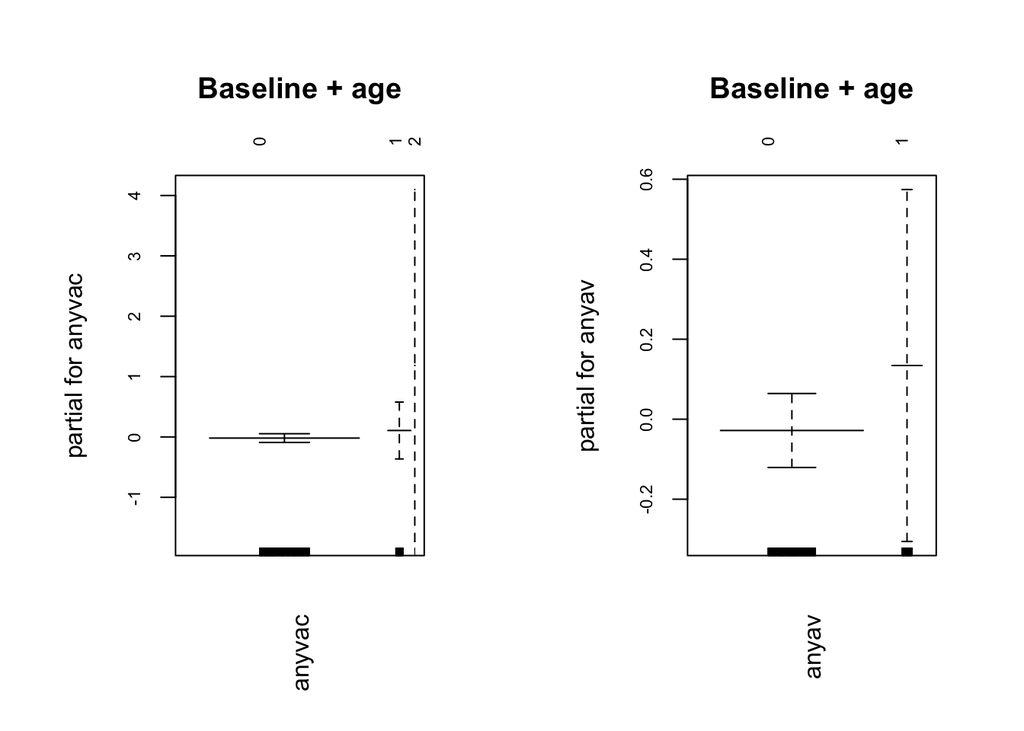

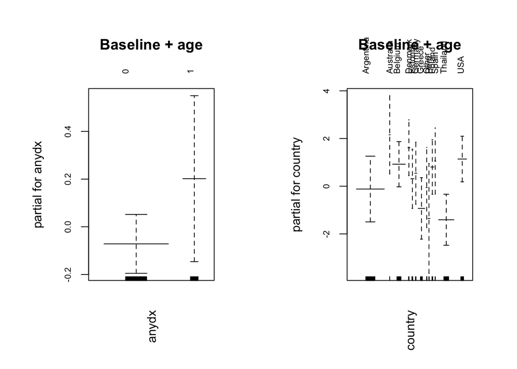

```r
plot.gam(fit1, se = T, col = 'dodgerblue', main = 'Baseline + age')
```

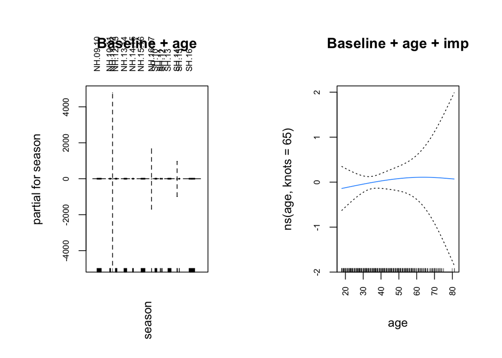

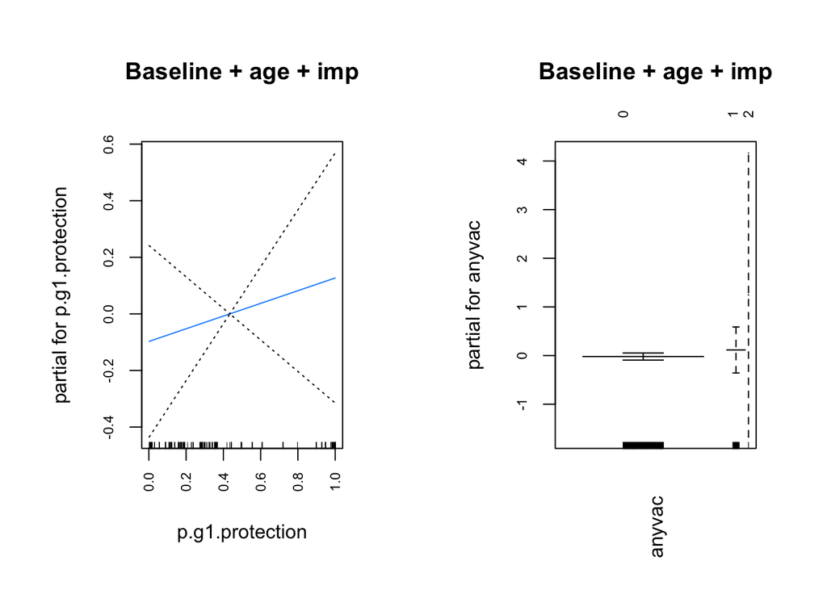

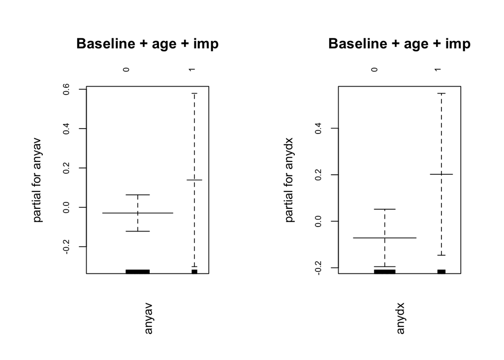

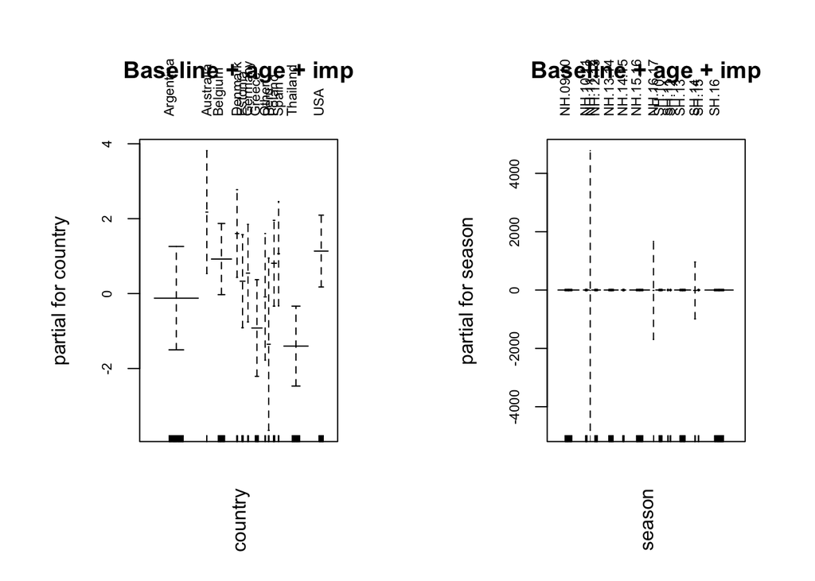

```r
plot.gam(fit2, se = T, col = 'dodgerblue', main = 'Baseline + age + imp')
```

```r
pdf('002Duration_H1N1.pdf')
plot.gam(fit2, se = T, col = 'dodgerblue', main = 'Baseline + age + imp')
dev.off()
```

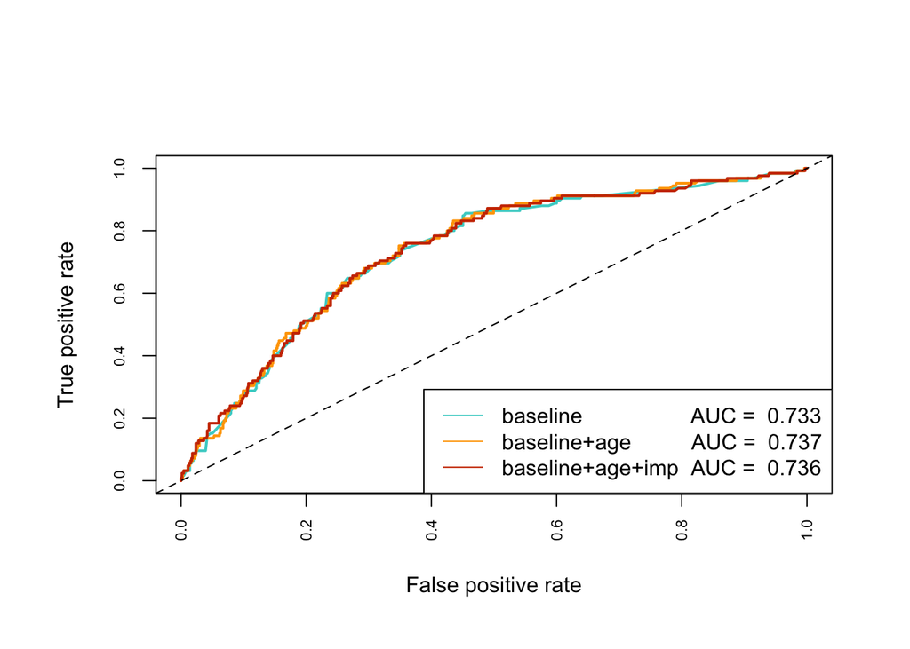

```r
## Test performance on test data
# Predict probs for each patient
probs0 = predict(fit0, newdata = test.H1N1, type = 'response')
probs1 = predict(fit1, newdata = test.H1N1, type = 'response')
probs2 = predict(fit2, newdata = test.H1N1, type = 'response')

# Create a predict object
pr0 = prediction(probs0, test.H1N1$prolonged.symp)
pr1 = prediction(probs1, test.H1N1$prolonged.symp)
pr2 = prediction(probs2, test.H1N1$prolonged.symp)

# Assess tp and fp
prf0 = performance(pr0, measure = 'tpr', x.measure = 'fpr')
prf1 = performance(pr1, measure = 'tpr', x.measure = 'fpr')
prf2 = performance(pr2, measure = 'tpr', x.measure = 'fpr')

# Calculate AUCs
auc = sapply(list(pr0, pr1, pr2), FUN = function(xx){aa = performance(xx, measure = 'auc')
                                                                      round(aa@y.values[[1]], 3) })

# Plot AUC
par(mfrow = c(1,1))
plot(prf0, lwd = 2, col = cols[3])
plot(prf1, col = cols[2], add = TRUE, lwd = 2)
plot(prf2, col = cols[1], add = TRUE, lwd = 2)
abline(a = 0, b = 1, lty = 2)
legend('bottomright', paste(c('baseline                  AUC = ', 'baseline+age          AUC = ', 'baseline+age+imp  AUC = '), auc), col = cols[3:1], lty = 1)
```

```r
pdf('002Duration_AUC_H1N1.pdf')
par(lwd = 3.5, cex = 1.5, cex.axis = 1.5, cex.lab = 1.5)
# Plot AUC
par(mfrow = c(1,1))
plot(prf0, col = cols[3])
plot(prf1, col = cols[2], add = TRUE)
plot(prf2, col = cols[1], add = TRUE)
abline(a = 0, b = 1)
legend('bottomright', paste(c('baseline                  AUC = ', 'baseline+age          AUC = ', 'baseline+age+imp  AUC = '), auc), col = cols[3:1], lty = 1, bty = 'n', cex = 1.5)
dev.off()
```

```r
AIC = c(fit0$aic, fit1$aic, fit2$aic); names(AIC) =  c('baseline', 'baeline+age', 'baseline+age+imp')
del.AIC = sort(AIC - min(AIC))
del.AIC
```

```
##         baseline      baeline+age baseline+age+imp
##         0.000000         2.477803         4.146353
```

```r
load('master.AIC.table.H1N1.RData')
master.AIC.table['002Prolonged',  c('baseline', 'baseline+age', 'baseline+age+imp')] = AIC - min(AIC)
save(master.AIC.table, file = 'master.AIC.table.H1N1.RData')
rm(master.AIC.table)
```

### Clean H3N2 data for fitting

```
##
## Argentina Australia   Belgium     Chile   Denmark   Estonia   Germany
##       850        15       274         4        22        28        24
##    Greece     Japan      Peru    Poland     Spain  Thailand        UK
##         6        10        79        50         9       519         6
##       USA
##       118
```

```
## [1] 2014
```

```r
## H3N2 fit to country, season and medical history only (no effect of age or imprinting)
fit0 = glm(prolonged.symp ~ anyvac + anyav + anydx + country + season, data = train.H3N2, family = binomial)
summary(fit0)
```

```
##
## Call:
## glm(formula = prolonged.symp ~ anyvac + anyav + anydx + country +
##     season, family = binomial, data = train.H3N2)
##
## Deviance Residuals:
##     Min       1Q   Median       3Q      Max
## -1.4731  -0.4817  -0.3553  -0.2038   2.8960
##
## Coefficients:
##                   Estimate Std. Error z value Pr(>|z|)
## (Intercept)       -17.1625   772.9316  -0.022 0.982285
## anyvac1            -0.2278     0.2544  -0.896 0.370517
## anyvac2           -15.2997  1250.8524  -0.012 0.990241
## anyav1             -0.2497     0.3122  -0.800 0.423866
## anydx1              0.2718     0.2173   1.251 0.211077
## countryAustralia    2.6682     0.7718   3.457 0.000546 ***
## countryBelgium      1.9509     0.6479   3.011 0.002604 **
## countryDenmark      1.7734     0.8948   1.982 0.047503 *
## countryEstonia      1.8030     0.8070   2.234 0.025473 *
## countryGermany      2.6154     0.8313   3.146 0.001655 **
## countryOther        2.5535     0.7082   3.606 0.000311 ***
## countryPeru         0.6737     0.5636   1.195 0.231925
## countryPoland       1.5567     0.7832   1.988 0.046860 *
## countryThailand    -0.8940     0.5740  -1.558 0.119350
## countryUSA          2.4512     0.6946   3.529 0.000418 ***
## seasonNH.11.12     14.6886   772.9315   0.019 0.984838
## seasonNH.12.13     13.9483   772.9315   0.018 0.985602
## seasonNH.13.14     14.5544   772.9315   0.019 0.984977
## seasonNH.14.15     14.1068   772.9314   0.018 0.985439
## seasonNH.15.16     14.1925   772.9319   0.018 0.985350
## seasonNH.16.17     13.8784   772.9316   0.018 0.985674
## seasonSH.10        15.6395   772.9321   0.020 0.983857
## seasonSH.11        15.0098   772.9317   0.019 0.984507
## seasonSH.12        14.2938   772.9319   0.018 0.985246
## seasonSH.13        14.6590   772.9318   0.019 0.984869
## seasonSH.14        15.0232   772.9316   0.019 0.984493
## seasonSH.15        14.2341   772.9316   0.018 0.985307
## seasonSH.16        13.1221   772.9324   0.017 0.986455
## ---
## Signif. codes:  0 '***' 0.001 '**' 0.01 '*' 0.05 '.' 0.1 ' ' 1
##
## (Dispersion parameter for binomial family taken to be 1)
##
##     Null deviance: 923.75  on 1173  degrees of freedom
## Residual deviance: 776.34  on 1146  degrees of freedom
## AIC: 832.34
##
## Number of Fisher Scoring iterations: 15
```

```r
## H3N2 fit to age only, plus fixed effects of vaccination, av use, underlying conditions, country and season
fit1 = glm(prolonged.symp ~ ns(age, knots = 65) + anyvac + anyav + anydx + country + season, data = train.H3N2, family = binomial)
summary(fit1)
```

```
##
## Call:
## glm(formula = prolonged.symp ~ ns(age, knots = 65) + anyvac +
##     anyav + anydx + country + season, family = binomial, data = train.H3N2)
##
## Deviance Residuals:
##     Min       1Q   Median       3Q      Max
## -1.4400  -0.4977  -0.3600  -0.2026   2.8906
##
## Coefficients:
##                       Estimate Std. Error z value Pr(>|z|)
## (Intercept)           -17.0747   774.0117  -0.022 0.982400
## ns(age, knots = 65)1    0.2065     0.6245   0.331 0.740931
## ns(age, knots = 65)2    0.5436     0.7983   0.681 0.495912
## anyvac1                -0.2473     0.2589  -0.955 0.339505
## anyvac2               -15.3415  1264.1450  -0.012 0.990317
## anyav1                 -0.2628     0.3127  -0.840 0.400740
## anydx1                  0.2499     0.2239   1.116 0.264358
## countryAustralia        2.6891     0.7728   3.480 0.000502 ***
## countryBelgium          1.9348     0.6516   2.969 0.002986 **
## countryDenmark          1.7643     0.8949   1.972 0.048666 *
## countryEstonia          1.7926     0.8076   2.220 0.026441 *
## countryGermany          2.6308     0.8342   3.154 0.001612 **
## countryOther            2.5249     0.7115   3.549 0.000387 ***
## countryPeru             0.6782     0.5642   1.202 0.229302
## countryPoland           1.5398     0.7839   1.964 0.049500 *
## countryThailand        -0.9203     0.5768  -1.596 0.110555
## countryUSA              2.4356     0.6949   3.505 0.000457 ***
## seasonNH.11.12         14.6437   774.0115   0.019 0.984906
## seasonNH.12.13         13.9134   774.0114   0.018 0.985658
## seasonNH.13.14         14.5224   774.0115   0.019 0.985031
## seasonNH.14.15         14.0532   774.0114   0.018 0.985514
## seasonNH.15.16         14.1432   774.0118   0.018 0.985421
## seasonNH.16.17         13.8477   774.0116   0.018 0.985726
## seasonSH.10            15.6319   774.0121   0.020 0.983887
## seasonSH.11            14.9522   774.0117   0.019 0.984588
## seasonSH.12            14.2409   774.0119   0.018 0.985321
## seasonSH.13            14.6206   774.0118   0.019 0.984929
## seasonSH.14            14.9692   774.0116   0.019 0.984570
## seasonSH.15            14.1757   774.0116   0.018 0.985388
## seasonSH.16            13.0706   774.0124   0.017 0.986527
## ---
## Signif. codes:  0 '***' 0.001 '**' 0.01 '*' 0.05 '.' 0.1 ' ' 1
##
## (Dispersion parameter for binomial family taken to be 1)
##
##     Null deviance: 923.75  on 1173  degrees of freedom
## Residual deviance: 775.86  on 1144  degrees of freedom
## AIC: 835.86
##
## Number of Fisher Scoring iterations: 15
```

```r
## H3N2 fit to age plus imprinting, plus fixed effects of vaccination, av use, underlying conditions, country and season
fit2 = glm(prolonged.symp ~ ns(age, knots = 65) + p.g2.protection + anyvac + anyav + anydx + country + season, data = train.H3N2, family = binomial)
summary(fit2)
```

```
##
## Call:
## glm(formula = prolonged.symp ~ ns(age, knots = 65) + p.g2.protection +
##     anyvac + anyav + anydx + country + season, family = binomial,
##     data = train.H3N2)
##
## Deviance Residuals:
##     Min       1Q   Median       3Q      Max
## -1.4435  -0.4980  -0.3580  -0.2022   2.8864
##
## Coefficients:
##                        Estimate Std. Error z value Pr(>|z|)
## (Intercept)           -17.03282  774.51115  -0.022 0.982455
## ns(age, knots = 65)1    0.15235    0.86080   0.177 0.859520
## ns(age, knots = 65)2    0.50058    0.92779   0.540 0.589517
## p.g2.protection        -0.03396    0.37182  -0.091 0.927220
## anyvac1                -0.24700    0.25895  -0.954 0.340159
## anyvac2               -15.34852 1262.62130  -0.012 0.990301
## anyav1                 -0.26112    0.31321  -0.834 0.404453
## anydx1                  0.25055    0.22400   1.118 0.263357
## countryAustralia        2.68860    0.77276   3.479 0.000503 ***
## countryBelgium          1.93269    0.65209   2.964 0.003038 **
## countryDenmark          1.76181    0.89530   1.968 0.049087 *
## countryEstonia          1.79465    0.80791   2.221 0.026327 *
## countryGermany          2.63022    0.83424   3.153 0.001617 **
## countryOther            2.52553    0.71166   3.549 0.000387 ***
## countryPeru             0.67570    0.56485   1.196 0.231596
## countryPoland           1.54093    0.78399   1.965 0.049359 *
## countryThailand        -0.92195    0.57723  -1.597 0.110221
## countryUSA              2.43229    0.69589   3.495 0.000474 ***
## seasonNH.11.12         14.63429  774.51084   0.019 0.984925
## seasonNH.12.13         13.90282  774.51081   0.018 0.985678
## seasonNH.13.14         14.50941  774.51085   0.019 0.985054
## seasonNH.14.15         14.04318  774.51079   0.018 0.985534
## seasonNH.15.16         14.13336  774.51121   0.018 0.985441
## seasonNH.16.17         13.84004  774.51095   0.018 0.985743
## seasonSH.10            15.62046  774.51142   0.020 0.983909
## seasonSH.11            14.93949  774.51102   0.019 0.984611
## seasonSH.12            14.22624  774.51123   0.018 0.985345
## seasonSH.13            14.60801  774.51116   0.019 0.984952
## seasonSH.14            14.95629  774.51100   0.019 0.984593
## seasonSH.15            14.16300  774.51100   0.018 0.985410
## seasonSH.16            13.06005  774.51172   0.017 0.986546
## ---
## Signif. codes:  0 '***' 0.001 '**' 0.01 '*' 0.05 '.' 0.1 ' ' 1
##
## (Dispersion parameter for binomial family taken to be 1)
##
##     Null deviance: 923.75  on 1173  degrees of freedom
## Residual deviance: 775.86  on 1143  degrees of freedom
## AIC: 837.86
##
## Number of Fisher Scoring iterations: 15
```

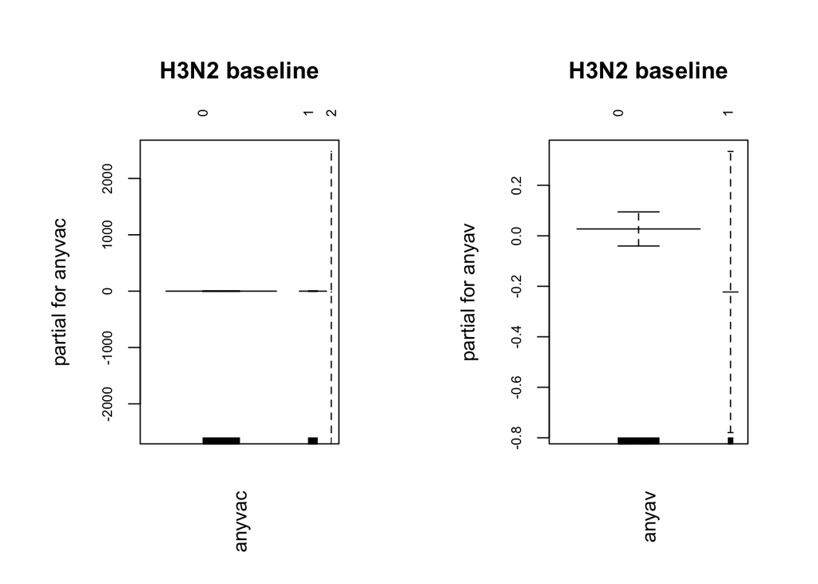

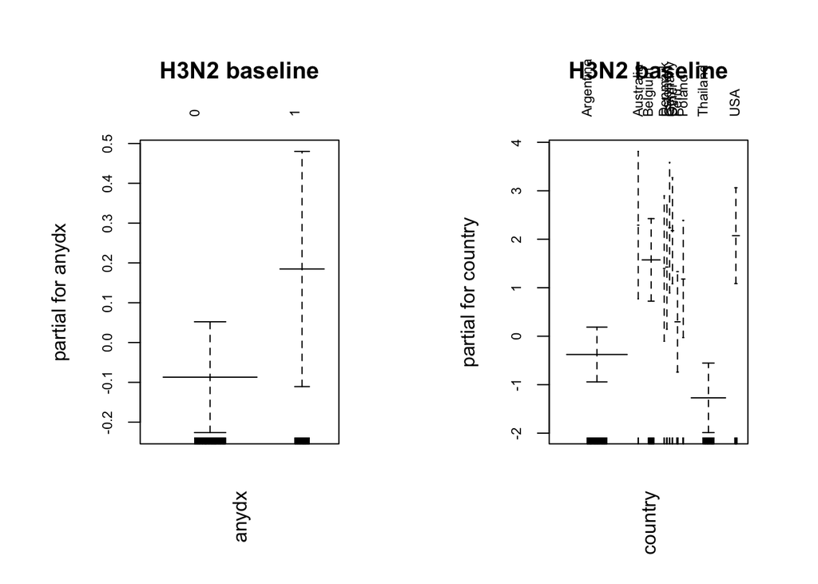

```r
## Plot the fits for each model side by side
par(mfrow = c(1, 2), las = 3, mar = c(6, 6, 6, 3), cex.axis = .7)
library(gam)
plot.gam(fit0, se = T, col = 'firebrick1', main = 'H3N2 baseline')
```

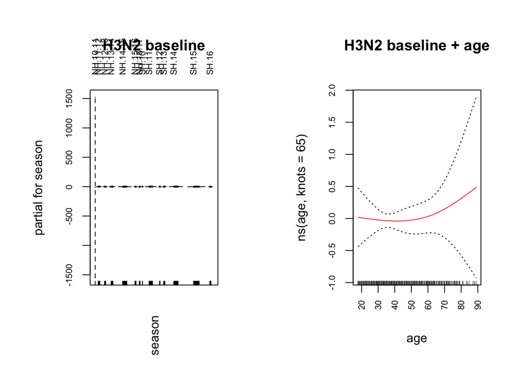

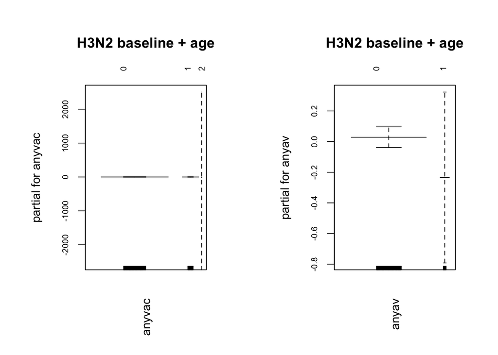

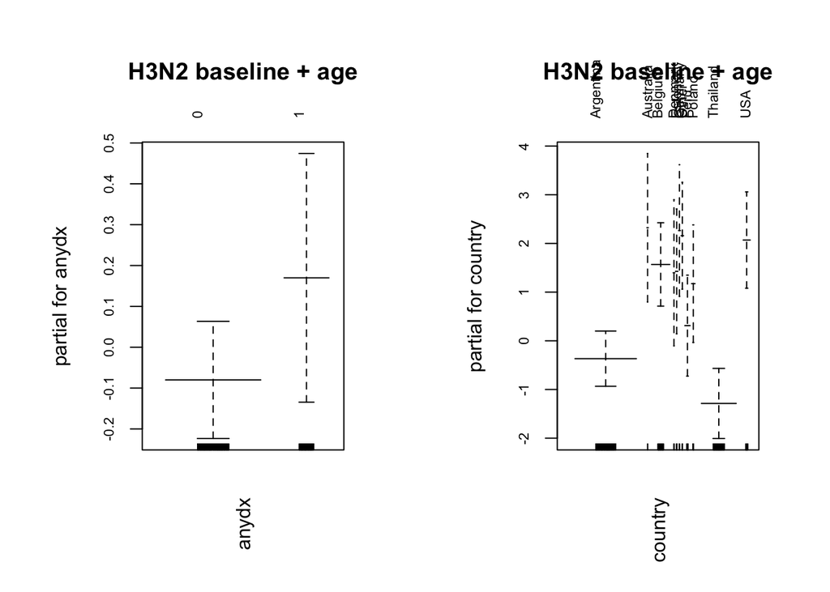

```r
plot.gam(fit1, se = T, col = 'firebrick1', main = 'H3N2 baseline + age')
```

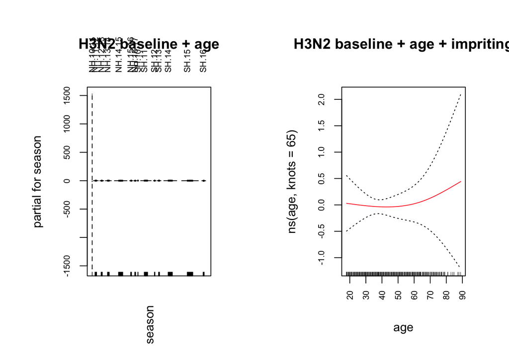

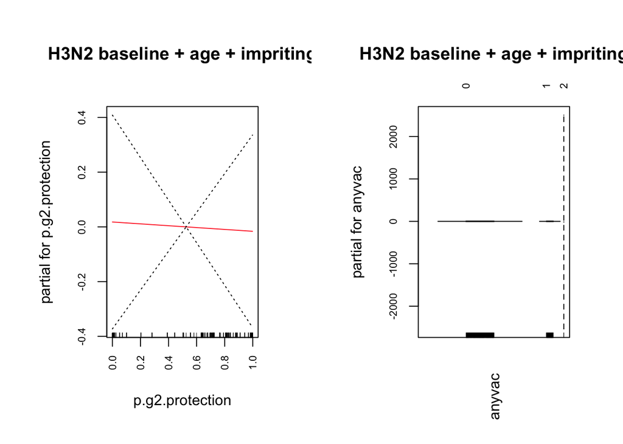

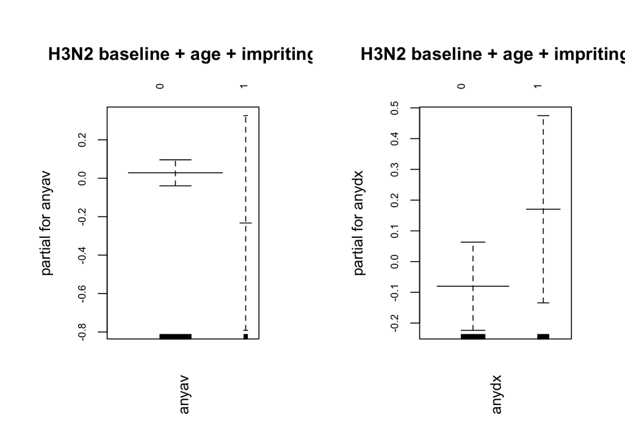

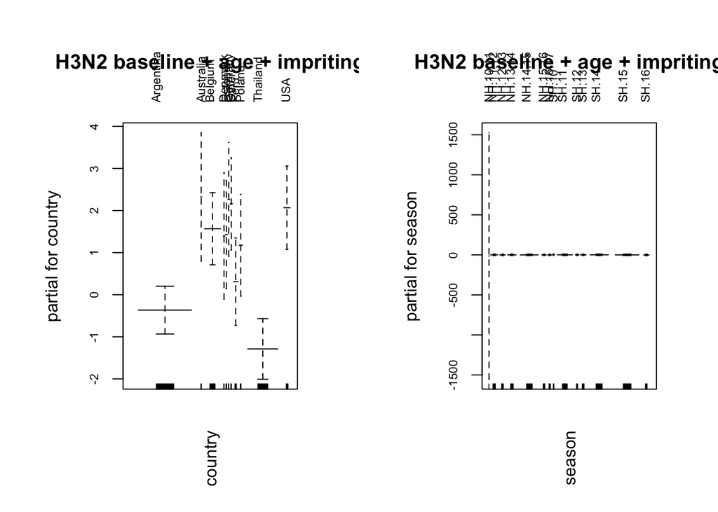

```r
plot.gam(fit2, se = T, col = 'firebrick1', main = 'H3N2 baseline + age + impriting')
```

```r
pdf('002Duration_H3N2.pdf')
plot.gam(fit2, se = T, col = 'firebrick1', main = 'H3N2 baseline + age + impriting')
dev.off()
```

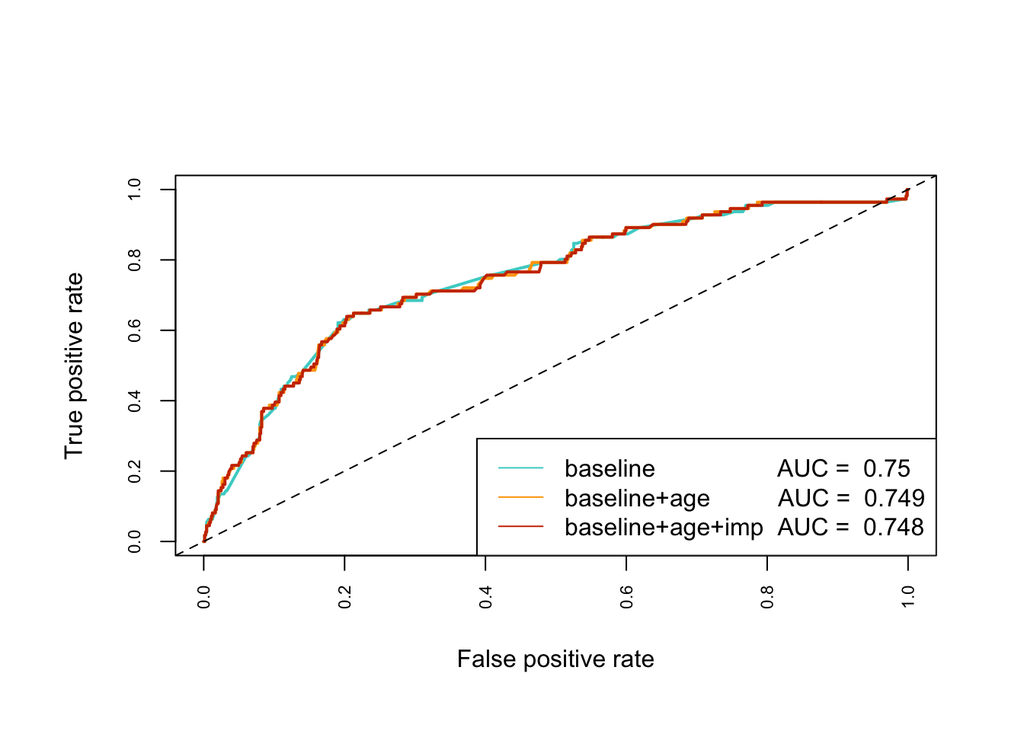

```r
## Test performance on test data
# Predict probs for each patient
probs0 = predict(fit0, newdata = test.H3N2, type = 'response')
probs1 = predict(fit1, newdata = test.H3N2, type = 'response')
probs2 = predict(fit2, newdata = test.H3N2, type = 'response')

# Create a predict object
pr0 = prediction(probs0, test.H3N2$prolonged.symp)
pr1 = prediction(probs1, test.H3N2$prolonged.symp)
pr2 = prediction(probs2, test.H3N2$prolonged.symp)

# Assess tp and fp
prf0 = performance(pr0, measure = 'tpr', x.measure = 'fpr')
prf1 = performance(pr1, measure = 'tpr', x.measure = 'fpr')
prf2 = performance(pr2, measure = 'tpr', x.measure = 'fpr')

# Calculate AUCs
auc = sapply(list(pr0, pr1, pr2), FUN = function(xx){aa = performance(xx, measure = 'auc')
                                                                      round(aa@y.values[[1]], 3) })

# Plot AUC
par(mfrow = c(1,1))
plot(prf0, lwd = 2, col = cols[3])
plot(prf1, col = cols[2], add = TRUE, lwd = 2)
plot(prf2, col = cols[1], add = TRUE, lwd = 2)
abline(a = 0, b = 1, lty = 2)
legend('bottomright', paste(c('baseline                  AUC = ', 'baseline+age          AUC = ', 'baseline+age+imp  AUC = '), auc), col = cols[3:1], lty = 1)
```

```r
pdf('002Duration_AUC_H3N2.pdf')
par(lwd = 3.5, cex = 1.5, cex.axis = 1.5, cex.lab = 1.5)
# Plot AUC
par(mfrow = c(1,1))
plot(prf0, col = cols[3])
plot(prf1, col = cols[2], add = TRUE)
plot(prf2, col = cols[1], add = TRUE)
abline(a = 0, b = 1)
legend('bottomright', paste(c('baseline                  AUC = ', 'baseline+age          AUC = ', 'baseline+age+imp  AUC = '), auc), col = cols[3:1], lty = 1, bty = 'n', cex = 1.5)
dev.off()
```

```r
AIC = c(fit0$aic, fit1$aic, fit2$aic); names(AIC) =  c('baseline', 'baeline+age', 'baseline+age+imp')
del.AIC = sort(AIC - min(AIC))
del.AIC
```

```
##         baseline      baeline+age baseline+age+imp
##         0.000000         3.522122         5.513771
```

```r
load('master.AIC.table.H3N2.RData')
master.AIC.table['002Prolonged',  c('baseline', 'baseline+age', 'baseline+age+imp')] = AIC - min(AIC)
save(master.AIC.table, file = 'master.AIC.table.H3N2.RData')
rm(master.AIC.table)
```